# Data analysis practical week 2 - part 2b

Molecular and Genetic Epidemiology Module

Antonio J Berlanga-Taylor, Ioanna Tzoulaki and Raha Pazoki

January 2019

### Questions

- How can we analyse genetic, molecular and phenotypic data when we have thousands of measurements per individual?

### Objectives

- Understand the concept of a QTL
- Run a QTL analysis with simulated data using MatrixEQTL
- Understand the output and interpret the results

## Preliminaries

1. Get the files and setup a working directory:
1. Clone or download scripts and data from [Antonio’s GitHub repository](https://github.com/AntonioJBT/teaching_ICL):
   - Download the code and data folders directly using bash (if you’re on a Mac, Linux or have e.g. [gitforwindows](http://gitforwindows.org/)):

```
pwd
cd ~/Desktop/
wget https://github.com/AntonioJBT/teaching_ICL/archive/master.zip
unzip master.zip
cd teaching_ICL-master
mkdir my_results
cd my_results
```

2. Alternatively:
   - Open a browser and go to the GitHub repository, look for the “Clone or download” link on the right hand side and press “Download ZIP”
   - Go to where you saved the folder, unzip it, create a folder called ‘my_results’ and enter it
2. Open RStudio and this script:
- You can save this file with a different name if you want
- We’ll be executing, adding and modifying code along the way
- If you have the .nb.html version, download the .Rmd file first and save that one with a different name
3. Start the exercises :-D

### Notebook setup

We’ll first need to specify in R where we want to run the analysis from. If you followed the instructions above you can set your working directory to the same location. This is much easier to do manually from the R console. Copy and paste the following:

```
setwd('~/Desktop/teaching_ICL-master/my_results/')
getwd()
```

#### Saving results

Normally we would prefer to keep code, data and results in separate directories. Here we’re using R Notebook and the knitr package to run commands, create output and produce a nice looking report file which contains code, text and results together. This R notebook let us have it all in one place, which can sometimes be very useful, particularly for exploratory analysis.

We’ll setup a separate path to a ‘results’ directory for plots that we might want to save independently though. We also already have a separate ‘data’ folder where we keep our data sets.

In a standard R script we would simply use commands such as setwd(), source(), etc. An important caveat here is that, by default, knitr uses the same directory as your .Rmd file to find any files that are necessary to run the code (e.g. any data files) and, if any output is generated, it???ll be saved in that directory as well. This is set independently for each code chunk.

To make it easier we can add an output path to make sure we save to the directory we want:

```r
path_results <- '../my_results/'
```

#### Load packages

You may need to install them first, e.g.:

```
source("https://bioconductor.org/biocLite.R")
biocLite()
biocLite('package')
```

```r
library(knitr)
library(plyr) # check the tidyverse packages if you're not familiar with them yet
library(MatrixEQTL) # run regression analysis efficiently for millions to billions of tests
# library(data.table) # reads, writes, processes data frames very quickly and can handle large sets
```

### Brief introduction to the analysis practical

In the previous exercise we analysed candidate markers using regression association tests. Here, we’ll perform the same type of analysis for thousands of genetic variants and molecular phenotypes.

### Data

The data we’ll be using consists of (badly) simulated sets. We have only simulated a few characteristics of the data but it is not an attempt to characterise genetic or molecular markers in a serious way. The data contains single nucleotide polymorphisms and molecular data (such as gene expression or metabolite data points).

We can assume that the data has already been quality controlled and all the pre-processing steps have been carried out.

## Analysis

### Load and inspect the data

What are the names of the input files?

Name them once here and if they change you only need to change the code once. (e.g. if you get new data, start a different project using the same analysis code, etc.).

Small files are on GitHub but you can create larger ones if wanted with the simulation scripts in the code directory. See the README file in the data directory for a few more instructions.

```r
input_gex <- '../data/100_cont_var_sim_data.tsv'
input_SNP <- '../data/100_plink.A-transpose.matrixQTL.geno'
input_covariates <- '../data/100_cov_sim_data.tsv'
```

When say covariates in this context, what are we actually referring to?

### SNP and gene positions

Here we’ll assume the data is from metabolites so we won’t include locations.

```r
#input_snpsPos <- '../data/snpsloc.txt'
#input_genePos <- '../data/geneloc.txt'
```

#### Output files

We’ll be saving some results, we can define the names of the files here:

```r
output_file_name <- sprintf('%s/QTL_analysis_larger.mxqtl.tsv', path_results)
output_file_name
```

```
## [1] "../my_results//QTL_analysis_larger.mxqtl.tsv"
```

```r
output_file_name.cis <- sprintf('%s/QTL_analysis_larger.mxqtl.cis.tsv', path_results)
output_file_name.cis
```

```
## [1] "../my_results//QTL_analysis_larger.mxqtl.cis.tsv"
```

Let’s look at the molecular data:

```r
gex_data <- read.csv(input_gex, header = TRUE, stringsAsFactors = FALSE, sep = '\t')
gex_data[1:5, 1:5]
```

|  | X | per0 | per1 | per2 | per3 |
| --- | --- | --- | --- | --- | --- |
| 1 | var0 | 2.011442 | 2.088370 | 2.023364 | 2.124617 |
| 2 | var1 | 2.074929 | 2.211096 | 2.063707 | 2.052900 |
| 3 | var2 | 2.056794 | 2.061877 | 2.163006 | 2.019581 |
| 4 | var3 | 2.038805 | 2.014289 | 2.040542 | 2.104893 |
| 5 | var4 | 2.101088 | 2.164116 | 2.182344 | 2.170168 |

```r
dim(gex_data)
```

```
## [1] 100 101
```

```r
head(gex_data)
```

|  | X | per0 | per1 | per2 | per3 | per4 | per5 | per6 | per7 | per8 | per9 | per10 | per11 | per12 | per13 | per14 | per15 | per16 | per17 | per18 | per19 | per20 | per21 | per22 | per23 | per24 | per25 | per26 | per27 | … |
| --- | --- | --- | --- | --- | --- | --- | --- | --- | --- | --- | --- | --- | --- | --- | --- | --- | --- | --- | --- | --- | --- | --- | --- | --- | --- | --- | --- | --- | --- | --- |
| 1 | var0 | 2.011442 | 2.088370 | 2.023364 | 2.124617 | 2.043207 | 2.095079 | 2.069400 | 2.024087 | 2.111571 | 2.137879 | 2.169459 | 2.022072 | 2.131103 | 2.115789 | 2.234499 | 2.253012 | 2.073149 | 2.047296 | 2.023967 | 2.075503 | 2.009355 | 2.018345 | 2.133037 | 2.191077 | 2.049303 | 2.064051 | 2.005279 | 2.022800 | … |
| 2 | var1 | 2.074929 | 2.211096 | 2.063707 | 2.052900 | 2.137682 | 2.053164 | 2.053477 | 2.074990 | 2.011174 | 2.035060 | 2.101102 | 2.180639 | 2.098144 | 2.163494 | 2.165203 | 2.204626 | 2.059314 | 2.031074 | 2.054325 | 2.075833 | 2.104617 | 2.103240 | 2.005689 | 2.141973 | 2.036797 | 2.084357 | 2.086872 | 2.008598 | … |
| 3 | var2 | 2.056794 | 2.061877 | 2.163006 | 2.019581 | 2.038321 | 2.090762 | 2.018648 | 2.090228 | 2.173101 | 2.056665 | 2.077506 | 2.037416 | 2.158859 | 2.149417 | 2.035015 | 2.084495 | 2.004296 | 2.005495 | 2.055705 | 2.092248 | 2.303505 | 2.011173 | 2.072342 | 2.046796 | 2.037282 | 2.027269 | 2.157910 | 2.111681 | … |
| 4 | var3 | 2.038805 | 2.014289 | 2.040542 | 2.104893 | 2.153234 | 2.157153 | 2.021023 | 2.245018 | 2.141168 | 2.158501 | 2.083691 | 2.168898 | 2.105499 | 2.112552 | 2.119766 | 2.125697 | 2.011316 | 2.041335 | 2.085503 | 2.198012 | 2.038356 | 2.024247 | 2.042599 | 2.036818 | 2.035594 | 2.086310 | 2.060584 | 2.199725 | … |
| 5 | var4 | 2.101088 | 2.164116 | 2.182344 | 2.170168 | 2.141442 | 2.068159 | 2.108879 | 2.097156 | 2.149943 | 2.049467 | 2.034454 | 2.164879 | 2.016134 | 2.124823 | 2.077112 | 2.075390 | 2.066897 | 2.128280 | 2.064418 | 2.127831 | 2.014825 | 2.107898 | 2.116651 | 2.073797 | 2.213391 | 2.225219 | 2.002165 | 2.029172 | … |
| 6 | var5 | 2.156341 | 2.092661 | 2.120828 | 2.005311 | 2.083278 | 2.027598 | 2.120050 | 2.076072 | 2.021907 | 2.065123 | 2.026901 | 2.115666 | 2.157344 | 2.067911 | 2.158016 | 2.046247 | 2.039551 | 2.050377 | 2.000433 | 2.196172 | 2.116870 | 2.071545 | 2.097906 | 2.017351 | 2.066925 | 2.037657 | 2.159785 | 2.006697 | … |

```r
tail(gex_data)
```

|  | X | per0 | per1 | per2 | per3 | per4 | per5 | per6 | per7 | per8 | per9 | per10 | per11 | per12 | per13 | per14 | per15 | per16 | per17 | per18 | per19 | per20 | per21 | per22 | per23 | per24 | per25 | per26 | per27 | … |
| --- | --- | --- | --- | --- | --- | --- | --- | --- | --- | --- | --- | --- | --- | --- | --- | --- | --- | --- | --- | --- | --- | --- | --- | --- | --- | --- | --- | --- | --- | --- |
| 95 | var94 | 2.103887 | 2.038427 | 2.149283 | 2.120105 | 2.016497 | 2.176499 | 2.055535 | 2.089542 | 2.186500 | 2.075392 | 2.008470 | 2.015948 | 2.011971 | 2.026436 | 2.081968 | 2.063458 | 2.083857 | 2.036760 | 2.027807 | 2.152860 | 2.025742 | 2.203150 | 2.249451 | 2.055685 | 2.176532 | 2.038222 | 2.031333 | 2.026122 | … |
| 96 | var95 | 2.065304 | 2.206498 | 2.129452 | 2.084431 | 2.186320 | 2.041382 | 2.036318 | 2.064580 | 2.095630 | 2.074069 | 2.033692 | 2.132621 | 2.144647 | 2.061279 | 2.100286 | 2.033064 | 2.074804 | 2.049475 | 2.125122 | 2.122127 | 2.233504 | 2.211600 | 2.110691 | 2.101120 | 2.032501 | 2.045933 | 2.120864 | 2.057365 | … |
| 97 | var96 | 2.016791 | 2.085248 | 2.097354 | 2.006490 | 2.092052 | 2.035159 | 2.165079 | 2.064533 | 2.116274 | 2.047795 | 2.035982 | 2.051652 | 2.116461 | 2.064207 | 2.021570 | 2.100765 | 2.041177 | 2.021993 | 2.018527 | 2.241551 | 2.134369 | 2.058515 | 2.008668 | 2.024382 | 2.154429 | 2.199331 | 2.096926 | 2.142914 | … |
| 98 | var97 | 2.020087 | 2.017855 | 2.194399 | 2.053678 | 2.104882 | 2.113078 | 2.033168 | 2.146459 | 2.097667 | 2.020630 | 2.055787 | 2.163452 | 2.015692 | 2.094550 | 2.099763 | 2.015861 | 2.002885 | 2.055521 | 2.023244 | 2.053939 | 2.070609 | 2.168682 | 2.155172 | 2.008260 | 2.064932 | 2.097236 | 2.036412 | 2.050349 | … |
| 99 | var98 | 2.084305 | 2.029055 | 2.277346 | 2.044454 | 2.047451 | 2.094072 | 2.112970 | 2.087598 | 2.005401 | 2.009411 | 2.040173 | 2.108206 | 2.038491 | 2.145628 | 2.268704 | 2.056880 | 2.110078 | 2.064513 | 2.117390 | 2.109943 | 2.160764 | 2.177078 | 2.177942 | 2.035167 | 2.176002 | 2.032359 | 2.175299 | 2.212256 | … |
| 100 | var99 | 2.178538 | 2.110116 | 2.088305 | 2.030263 | 2.068371 | 2.099719 | 2.090179 | 2.035017 | 2.049467 | 2.025168 | 2.076735 | 2.083485 | 2.240671 | 2.100197 | 2.024716 | 2.039582 | 2.142664 | 2.057497 | 2.103508 | 2.043110 | 2.051802 | 2.009364 | 2.035705 | 2.052918 | 2.017160 | 2.022346 | 2.064644 | 2.026647 | … |

```r
str(gex_data, list.len = 10)
```

```
## 'data.frame':    100 obs. of  101 variables:
##  $ X    : chr  "var0" "var1" "var2" "var3" ...
##  $ per0 : num  2.01 2.07 2.06 2.04 2.1 ...
##  $ per1 : num  2.09 2.21 2.06 2.01 2.16 ...
##  $ per2 : num  2.02 2.06 2.16 2.04 2.18 ...
##  $ per3 : num  2.12 2.05 2.02 2.1 2.17 ...
##  $ per4 : num  2.04 2.14 2.04 2.15 2.14 ...
##  $ per5 : num  2.1 2.05 2.09 2.16 2.07 ...
##  $ per6 : num  2.07 2.05 2.02 2.02 2.11 ...
##  $ per7 : num  2.02 2.07 2.09 2.25 2.1 ...
##  $ per8 : num  2.11 2.01 2.17 2.14 2.15 ...
##   [list output truncated]
```

```r
class(gex_data)
```

```
## [1] "data.frame"
```

```r
colnames(gex_data)[1:10]
```

```
##  [1] "X"    "per0" "per1" "per2" "per3" "per4" "per5" "per6" "per7" "per8"
```

```r
rownames(gex_data)[1:10]
```

```
##  [1] "1"  "2"  "3"  "4"  "5"  "6"  "7"  "8"  "9"  "10"
```

Let’s plot a few of the variables just to check that our dataset is as we expect:

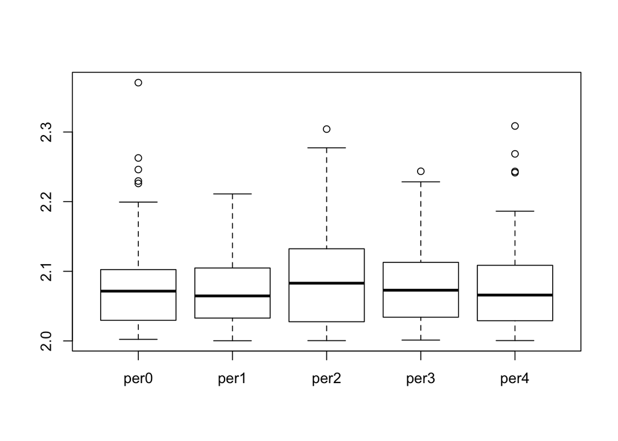

```r
boxplot(gex_data[, 2:6])
```

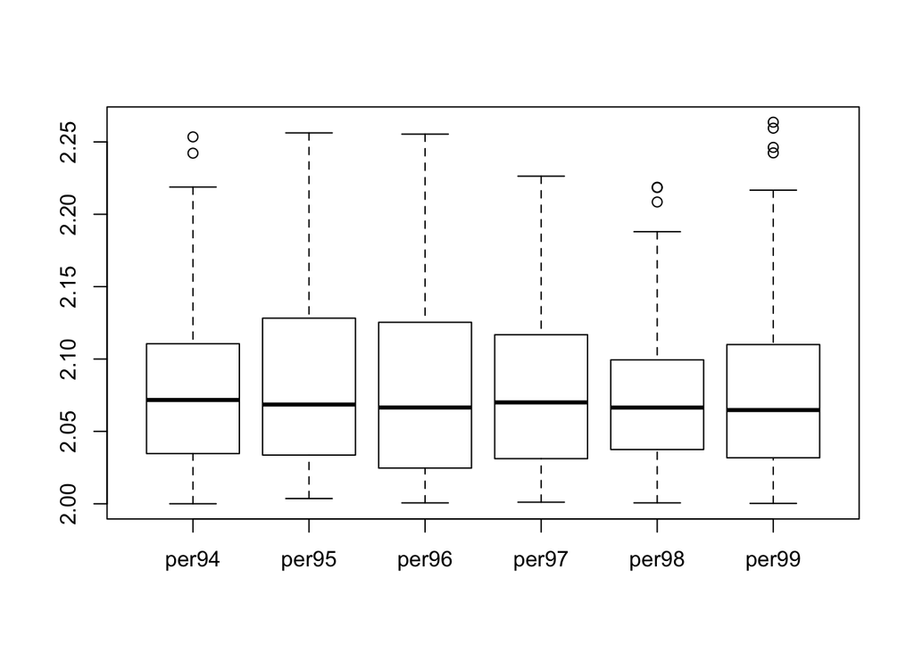

```r
boxplot(gex_data[, (ncol(gex_data)-5):ncol(gex_data)])
```

What are we actually plotting here? What are the columns and what are the rows?

What if we want to see how one (or more) of the measured molecules looks across all individuals?

This is a very quick look at the data, just for sanity, as we should have already made some pretty plots during the QC stage.

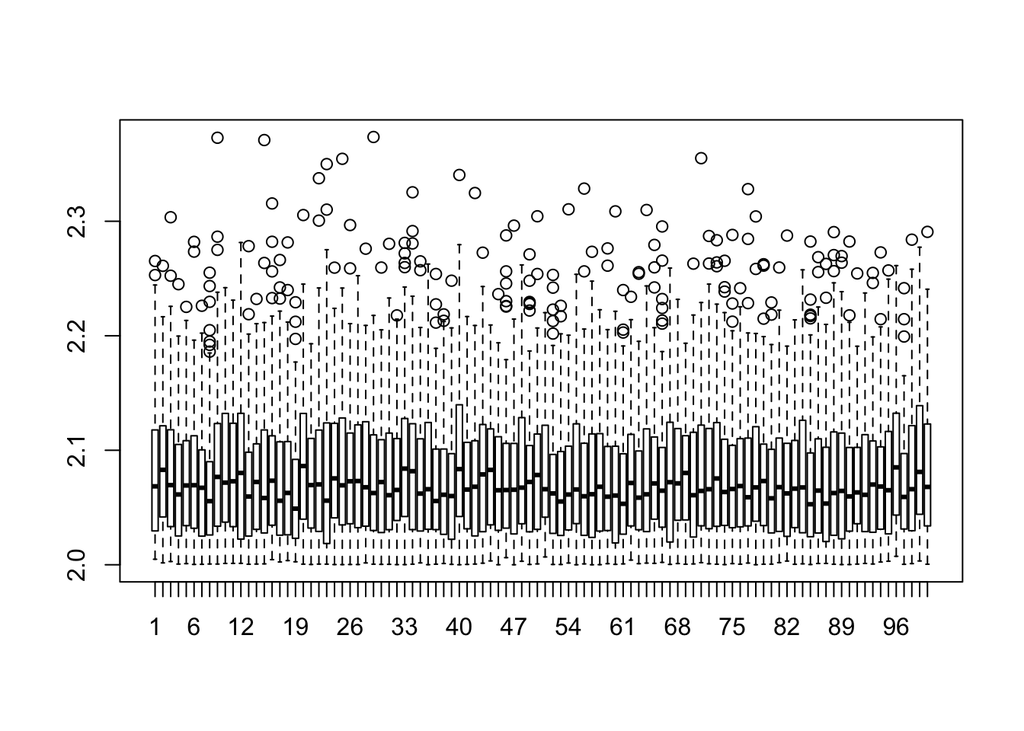

```r
boxplot(t(gex_data[, -1]))
```

Let’s look at the genetic data:

```r
SNP_data <- read.csv(input_SNP, header = TRUE, stringsAsFactors = FALSE, sep = '\t')
SNP_data[1:5, 1:5]
```

|  | SNP | per0_per0 | per1_per1 | per2_per2 | per3_per3 |
| --- | --- | --- | --- | --- | --- |
| 1 | snp0 | 2 | 0 | 1 | 0 |
| 2 | snp1 | 1 | 1 | 1 | 1 |
| 3 | snp2 | 2 | 1 | 1 | 2 |
| 4 | snp3 | 1 | 1 | 1 | 0 |
| 5 | snp4 | 2 | 0 | 1 | 1 |

```r
head(SNP_data)
```

|  | SNP | per0_per0 | per1_per1 | per2_per2 | per3_per3 | per4_per4 | per5_per5 | per6_per6 | per7_per7 | per8_per8 | per9_per9 | per10_per10 | per11_per11 | per12_per12 | per13_per13 | per14_per14 | per15_per15 | per16_per16 | per17_per17 | per18_per18 | per19_per19 | per20_per20 | per21_per21 | per22_per22 | per23_per23 | per24_per24 | per25_per25 | per26_per26 | per27_per27 | … |
| --- | --- | --- | --- | --- | --- | --- | --- | --- | --- | --- | --- | --- | --- | --- | --- | --- | --- | --- | --- | --- | --- | --- | --- | --- | --- | --- | --- | --- | --- | --- |
| 1 | snp0 | 2 | 0 | 1 | 0 | 1 | 1 | 1 | 0 | 2 | 0 | 1 | 0 | 0 | 1 | 1 | 1 | 1 | 0 | 1 | 1 | 0 | 2 | 1 | 1 | 1 | 1 | 1 | 1 | … |
| 2 | snp1 | 1 | 1 | 1 | 1 | 0 | 0 | 2 | 2 | 2 | 1 | 1 | 1 | 1 | 1 | 2 | 1 | 0 | 1 | 1 | 1 | 1 | 1 | 2 | 1 | 0 | 2 | 0 | 2 | … |
| 3 | snp2 | 2 | 1 | 1 | 2 | 2 | 2 | 0 | 1 | 2 | 1 | 0 | 1 | 0 | 0 | 1 | 1 | 1 | 2 | 2 | 0 | 2 | 1 | 1 | 0 | 1 | 2 | 1 | 1 | … |
| 4 | snp3 | 1 | 1 | 1 | 0 | 1 | 1 | 2 | 2 | 1 | 2 | 2 | 1 | 1 | 1 | 0 | 0 | 1 | 2 | 1 | 1 | 1 | 0 | 2 | 2 | 1 | 0 | 0 | 1 | … |
| 5 | snp4 | 2 | 0 | 1 | 1 | 1 | 0 | 1 | 0 | 1 | 0 | 1 | 2 | 2 | 2 | 1 | 1 | 1 | 1 | 0 | 1 | 1 | 1 | 1 | 1 | 1 | 1 | 1 | 1 | … |
| 6 | snp5 | 0 | 0 | 1 | 2 | 1 | 1 | 2 | 1 | 2 | 0 | 1 | 2 | 1 | 1 | 0 | 2 | 0 | 0 | 1 | 0 | 1 | 0 | 2 | 2 | 1 | 1 | 0 | 2 | … |

```r
tail(SNP_data)
```

|  | SNP | per0_per0 | per1_per1 | per2_per2 | per3_per3 | per4_per4 | per5_per5 | per6_per6 | per7_per7 | per8_per8 | per9_per9 | per10_per10 | per11_per11 | per12_per12 | per13_per13 | per14_per14 | per15_per15 | per16_per16 | per17_per17 | per18_per18 | per19_per19 | per20_per20 | per21_per21 | per22_per22 | per23_per23 | per24_per24 | per25_per25 | per26_per26 | per27_per27 | … |
| --- | --- | --- | --- | --- | --- | --- | --- | --- | --- | --- | --- | --- | --- | --- | --- | --- | --- | --- | --- | --- | --- | --- | --- | --- | --- | --- | --- | --- | --- | --- |
| 95 | snp94 | 1 | 0 | 1 | 1 | 2 | 0 | 1 | 1 | 1 | 0 | 1 | 1 | 2 | 2 | 1 | 1 | 2 | 1 | 0 | 0 | 0 | 1 | 1 | 1 | 1 | 2 | 1 | 0 | … |
| 96 | snp95 | 0 | 2 | 1 | 1 | 0 | 2 | 1 | 1 | 1 | 1 | 1 | 2 | 1 | 1 | 1 | 1 | 0 | 1 | 1 | 0 | 0 | 2 | 1 | 1 | 0 | 0 | 2 | 1 | … |
| 97 | snp96 | 1 | 1 | 1 | 2 | 1 | 1 | 1 | 2 | 0 | 1 | 1 | 2 | 1 | 2 | 1 | 1 | 0 | 1 | 2 | 2 | 1 | 1 | 1 | 1 | 0 | 2 | 2 | 1 | … |
| 98 | snp97 | 2 | 1 | 1 | 0 | 1 | 0 | 1 | 1 | 1 | 1 | 2 | 1 | 0 | 1 | 0 | 1 | 0 | 2 | 2 | 1 | 1 | 1 | 2 | 0 | 1 | 1 | 0 | 0 | … |
| 99 | snp98 | 2 | 2 | 1 | 1 | 0 | 0 | 1 | 1 | 1 | 2 | 1 | 1 | 1 | 1 | 0 | 1 | 0 | 0 | 1 | 1 | 2 | 2 | 1 | 2 | 1 | 2 | 1 | 1 | … |
| 100 | snp99 | 2 | 0 | 0 | 2 | 1 | 1 | 0 | 1 | 1 | 0 | 1 | 1 | 1 | 1 | 0 | 1 | 1 | 1 | 1 | 0 | 2 | 0 | 1 | 1 | 0 | 1 | 0 | 2 | … |

```r
str(SNP_data, list.len = 10)
```

```
## 'data.frame':    100 obs. of  101 variables:
##  $ SNP        : chr  "snp0" "snp1" "snp2" "snp3" ...
##  $ per0_per0  : int  2 1 2 1 2 0 1 1 1 1 ...
##  $ per1_per1  : int  0 1 1 1 0 0 2 0 2 0 ...
##  $ per2_per2  : int  1 1 1 1 1 1 1 1 1 0 ...
##  $ per3_per3  : int  0 1 2 0 1 2 2 0 2 1 ...
##  $ per4_per4  : int  1 0 2 1 1 1 1 0 1 1 ...
##  $ per5_per5  : int  1 0 2 1 0 1 1 1 1 2 ...
##  $ per6_per6  : int  1 2 0 2 1 2 2 1 1 2 ...
##  $ per7_per7  : int  0 2 1 2 0 1 1 0 0 2 ...
##  $ per8_per8  : int  2 2 2 1 1 2 0 2 1 1 ...
##   [list output truncated]
```

```r
dim(SNP_data)
```

```
## [1] 100 101
```

```r
class(SNP_data)
```

```
## [1] "data.frame"
```

```r
colnames(SNP_data)[1:10]
```

```
##  [1] "SNP"       "per0_per0" "per1_per1" "per2_per2" "per3_per3"
##  [6] "per4_per4" "per5_per5" "per6_per6" "per7_per7" "per8_per8"
```

```r
rownames(SNP_data)[1:10]
```

```
##  [1] "1"  "2"  "3"  "4"  "5"  "6"  "7"  "8"  "9"  "10"
```

Let’s plot a few of the variables just to check quickly that our dataset is as we expect:

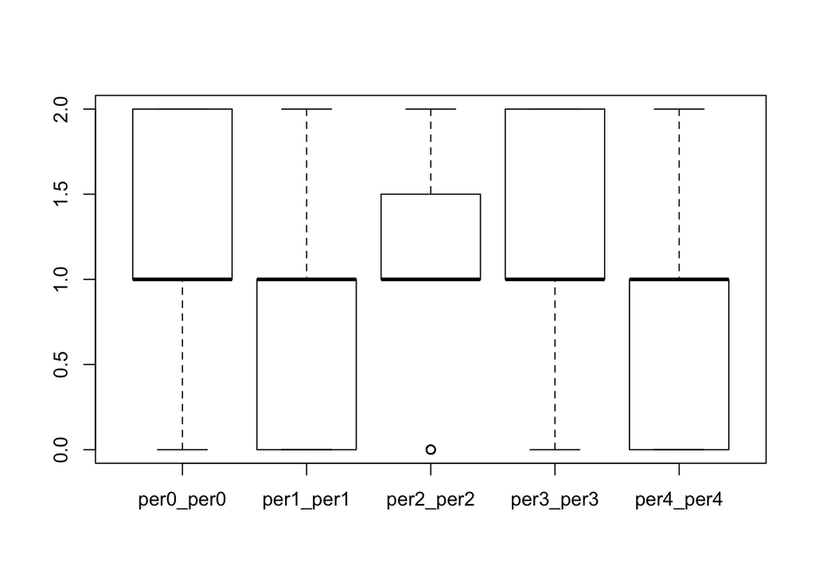

```r
boxplot(SNP_data[, 2:6])
```

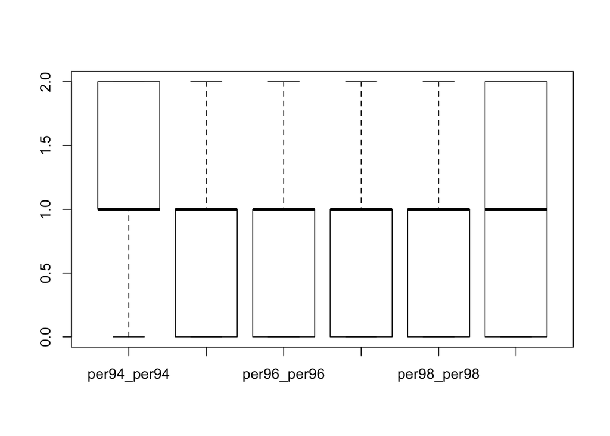

```r
boxplot(SNP_data[, (ncol(SNP_data)-5):ncol(SNP_data)])
```

What is this about?

SNP data in this file looks more like count data (number of minor alleles at that particular genomic location).

Simple counts or a table might be better here:

```r
as.data.frame(apply(SNP_data, 1, function(x) count(x))[1]) # rows
```

| x | freq |
| --- | --- |
| 0 | 30 |
| 1 | 48 |
| 2 | 22 |
| snp0 | 1 |

Let’s look at the covariates data:

```r
cov_data <- read.csv(input_covariates, header = TRUE, stringsAsFactors = FALSE, sep = '\t')
cov_data[1:5, 1:5]
```

|  | X | per0 | per1 | per2 | per3 |
| --- | --- | --- | --- | --- | --- |
| 1 | var0 | 2.716564 | 7.754125 | 4.642621 | 6.926951 |
| 2 | var1 | 15.027063 | 5.782866 | -1.872673 | 18.242020 |
| 3 | var2 | 10.979109 | 10.026883 | 10.237184 | 10.097399 |
| 4 | var3 | 7.378765 | 12.535880 | 8.579287 | 8.725308 |
| 5 | var4 | 9.844247 | 1.461214 | 2.813233 | 13.475994 |

```r
dim(cov_data)
```

```
## [1]  10 101
```

```r
head(cov_data)
```

|  | X | per0 | per1 | per2 | per3 | per4 | per5 | per6 | per7 | per8 | per9 | per10 | per11 | per12 | per13 | per14 | per15 | per16 | per17 | per18 | per19 | per20 | per21 | per22 | per23 | per24 | per25 | per26 | per27 | … |
| --- | --- | --- | --- | --- | --- | --- | --- | --- | --- | --- | --- | --- | --- | --- | --- | --- | --- | --- | --- | --- | --- | --- | --- | --- | --- | --- | --- | --- | --- | --- |
| 1 | var0 | 2.716564 | 7.754125 | 4.642621 | 6.926951 | 7.343646 | 9.869086 | 15.1116143 | 2.571390 | 6.173441 | 3.663875 | 10.719575 | 14.968585 | 15.934695 | -5.589116 | 24.57872 | 10.545607 | 10.825852 | 4.972631 | 0.0833596 | 17.996681 | 11.564243 | 16.263530 | 2.376563 | 5.510924 | 12.868239 | 1.830619 | 4.8177334 | -1.796053 | … |
| 2 | var1 | 15.027063 | 5.782866 | -1.872673 | 18.242020 | 10.969449 | 18.722471 | 12.6817509 | 6.395979 | 19.906280 | 7.129417 | 3.395888 | 5.681814 | 10.771372 | 13.584492 | 20.46511 | 6.497355 | 7.337784 | 13.577221 | 1.3292591 | 3.610318 | 12.601809 | 5.075939 | 6.909877 | 7.917458 | 6.584222 | 6.343480 | -0.2467608 | -0.396119 | … |
| 3 | var2 | 10.979109 | 10.026883 | 10.237184 | 10.097399 | 13.165302 | 15.210605 | 13.2285458 | 4.115239 | 6.399474 | 10.664086 | 4.961132 | 15.368549 | 7.829563 | 14.346220 | 14.55426 | 10.812307 | 8.880349 | 10.251066 | 8.6733839 | 9.415681 | 12.976134 | 8.534295 | 9.926829 | 9.891990 | 4.428454 | 4.580664 | 5.8328976 | 13.410655 | … |
| 4 | var3 | 7.378765 | 12.535880 | 8.579287 | 8.725308 | 2.007193 | 14.330798 | 18.1710893 | 1.186859 | 13.814093 | 7.189667 | 12.922761 | 7.674022 | 1.203031 | 12.410097 | 12.64324 | 8.552466 | 13.073252 | 26.326655 | 6.1810790 | 3.916222 | 5.179807 | 9.219976 | 7.355951 | 10.185828 | 9.652456 | 13.219009 | 4.3056507 | 7.829785 | … |
| 5 | var4 | 9.844247 | 1.461214 | 2.813233 | 13.475994 | 12.986890 | -1.417745 | 0.9987122 | 6.364541 | 21.994677 | 6.158198 | 10.449507 | 3.270868 | 7.739068 | 4.276450 | 11.42265 | 14.339206 | 14.491101 | 9.333965 | 11.2375584 | 10.437481 | 2.595682 | 14.697699 | 16.164530 | 9.762268 | 15.582131 | 8.052802 | 13.1851013 | 18.351497 | … |
| 6 | var5 | 1.632863 | 10.688924 | 12.137117 | 13.563648 | 2.134887 | 10.509293 | 10.1513451 | 15.690753 | 18.446367 | 11.648068 | 8.082762 | 5.248082 | 4.636902 | 16.432347 | 12.06263 | 15.764030 | 9.010716 | 9.731559 | 11.4596334 | 12.077738 | 8.812707 | 7.097247 | 11.508161 | 11.524523 | 14.424605 | 14.576209 | 1.1299241 | 11.031206 | … |

```r
tail(cov_data)
```

|  | X | per0 | per1 | per2 | per3 | per4 | per5 | per6 | per7 | per8 | per9 | per10 | per11 | per12 | per13 | per14 | per15 | per16 | per17 | per18 | per19 | per20 | per21 | per22 | per23 | per24 | per25 | per26 | per27 | … |
| --- | --- | --- | --- | --- | --- | --- | --- | --- | --- | --- | --- | --- | --- | --- | --- | --- | --- | --- | --- | --- | --- | --- | --- | --- | --- | --- | --- | --- | --- | --- |
| 5 | var4 | 9.844247 | 1.461214 | 2.813233 | 13.475994 | 12.986890 | -1.417745 | 0.9987122 | 6.364541 | 21.994677 | 6.158198 | 10.449507 | 3.270868 | 7.739068 | 4.276450 | 11.422645 | 14.3392061 | 14.491101 | 9.3339654 | 11.237558 | 10.43748 | 2.595682 | 14.697699 | 16.164530 | 9.762268 | 15.58213 | 8.052802 | 13.185101 | 18.3514972 | … |
| 6 | var5 | 1.632863 | 10.688924 | 12.137117 | 13.563648 | 2.134887 | 10.509293 | 10.1513451 | 15.690753 | 18.446367 | 11.648068 | 8.082762 | 5.248082 | 4.636902 | 16.432347 | 12.062634 | 15.7640302 | 9.010716 | 9.7315594 | 11.459633 | 12.07774 | 8.812707 | 7.097247 | 11.508161 | 11.524523 | 14.42461 | 14.576209 | 1.129924 | 11.0312063 | … |
| 7 | var6 | 9.224804 | 15.038707 | 11.706595 | 6.963588 | 8.593823 | 12.724256 | 9.2786732 | 13.368394 | 8.782872 | 7.137007 | 16.180843 | 9.374680 | 7.415807 | 6.611785 | 4.874360 | 7.3892395 | 18.709101 | -0.5724435 | 19.110446 | 11.62946 | 13.544958 | 12.819448 | 14.084397 | 9.581310 | 15.05635 | 22.092275 | 14.916901 | 13.4192036 | … |
| 8 | var7 | 12.827653 | 11.980328 | 8.255040 | 13.700810 | 1.531767 | 8.084301 | 3.1051125 | 10.633310 | 13.137208 | 12.944661 | 11.441290 | 15.485686 | 13.996422 | 12.035794 | -3.857889 | 9.8234921 | 3.192186 | 11.7650909 | 10.522950 | 9.93961 | 11.397416 | 9.220894 | 3.114476 | 7.763712 | 10.47614 | 1.331153 | 13.049782 | 10.7172115 | … |
| 9 | var8 | 7.210589 | 13.623182 | 8.817582 | 6.748911 | 7.739639 | 1.410529 | 20.1948945 | 11.921878 | 10.045985 | -3.368629 | 16.791284 | 16.545590 | 11.958116 | 13.376205 | 4.958004 | 0.3612515 | 24.990943 | 11.0064218 | -4.154938 | 14.01216 | 18.546401 | 4.273169 | 4.354960 | 11.745359 | 12.37751 | 8.599292 | 15.613247 | 0.8934231 | … |
| 10 | var9 | 8.197405 | 6.235491 | 11.358322 | 6.886067 | 15.598166 | 11.869307 | 19.6296573 | 15.661149 | 6.823724 | 7.630835 | 6.780232 | 7.007279 | 19.582496 | 12.320254 | 10.537896 | 17.5426474 | 7.065638 | 5.3860521 | 10.051060 | 16.16551 | 14.142740 | 10.566769 | 13.678961 | 13.055810 | 1.39684 | 9.199209 | 19.955663 | 14.9145867 | … |

```r
str(cov_data, list.len = 10)
```

```
## 'data.frame':    10 obs. of  101 variables:
##  $ X    : chr  "var0" "var1" "var2" "var3" ...
##  $ per0 : num  2.72 15.03 10.98 7.38 9.84 ...
##  $ per1 : num  7.75 5.78 10.03 12.54 1.46 ...
##  $ per2 : num  4.64 -1.87 10.24 8.58 2.81 ...
##  $ per3 : num  6.93 18.24 10.1 8.73 13.48 ...
##  $ per4 : num  7.34 10.97 13.17 2.01 12.99 ...
##  $ per5 : num  9.87 18.72 15.21 14.33 -1.42 ...
##  $ per6 : num  15.112 12.682 13.229 18.171 0.999 ...
##  $ per7 : num  2.57 6.4 4.12 1.19 6.36 ...
##  $ per8 : num  6.17 19.91 6.4 13.81 21.99 ...
##   [list output truncated]
```

```r
class(cov_data)
```

```
## [1] "data.frame"
```

```r
colnames(cov_data)[1:10]
```

```
##  [1] "X"    "per0" "per1" "per2" "per3" "per4" "per5" "per6" "per7" "per8"
```

```r
rownames(cov_data)[1:10]
```

```
##  [1] "1"  "2"  "3"  "4"  "5"  "6"  "7"  "8"  "9"  "10"
```

What could these variables represent?

We can assume we ran principle components analysis on our data beforehand and we’ll use these as possible confounders.

```r
summary(cov_data[, 1:10])
```

```
##       X                  per0             per1             per2
##  Length:10          Min.   : 1.633   Min.   : 1.461   Min.   :-1.873
##  Class :character   1st Qu.: 7.253   1st Qu.: 6.615   1st Qu.: 5.546
##  Mode  :character   Median : 8.711   Median :10.358   Median : 8.698
##                     Mean   : 8.504   Mean   : 9.513   Mean   : 7.667
##                     3rd Qu.:10.695   3rd Qu.:12.397   3rd Qu.:11.078
##                     Max.   :15.027   Max.   :15.039   Max.   :12.137
##       per3             per4             per5             per6
##  Min.   : 6.749   Min.   : 1.532   Min.   :-1.418   Min.   : 0.9987
##  1st Qu.: 6.936   1st Qu.: 3.437   1st Qu.: 8.530   1st Qu.: 9.4968
##  Median : 9.411   Median : 8.167   Median :11.189   Median :12.9551
##  Mean   :10.533   Mean   : 8.207   Mean   :10.131   Mean   :12.2551
##  3rd Qu.:13.542   3rd Qu.:12.483   3rd Qu.:13.929   3rd Qu.:17.4062
##  Max.   :18.242   Max.   :15.598   Max.   :18.722   Max.   :20.1949
##       per7             per8
##  Min.   : 1.187   Min.   : 6.173
##  1st Qu.: 4.678   1st Qu.: 7.314
##  Median : 8.515   Median :11.592
##  Mean   : 8.791   Mean   :12.552
##  3rd Qu.:13.007   3rd Qu.:17.288
##  Max.   :15.691   Max.   :21.995
```

### Basic sanity

Let’s double check that the order between files matches, often this is essential as silent errors can happen if they don’t.

```r
identical(colnames(gex_data), colnames(SNP_data))
```

```
## [1] FALSE
```

```r
identical(colnames(gex_data), colnames(cov_data))
```

```
## [1] TRUE
```

```r
identical(rownames(gex_data), rownames(cov_data))
```

```
## [1] FALSE
```

### Running QTL analysis with MatrixEQTL

[MatrixEQTL is an R package](http://www.bios.unc.edu/research/genomic_software/Matrix_eQTL/) ([and its paper](https://academic.oup.com/bioinformatics/article/28/10/1353/213326)) that can handle billions of comparisons efficiently. It runs regression tests on SNP data and a continuous variable such as gene expression or metabolite abundance levels. See the tutorial online and the original paper to understand more about the use of linear algebra and what each of the parameters means. Some of the data that we are using are from their examples.

We’ll set up the parameters that we need for MatrixEQTL here. I’ve commented out some of the variables we don’t need to set in this particular analysis:

```r
useModel <- modelLINEAR # modelANOVA or modelLINEAR or modelLINEAR_CROSS

# The p-value threshold determines which gene-SNP associations are saved in the output file.
# Note that for larger datasets the threshold should be lower. Setting the threshold to a high value for a large dataset may cause excessively large output files.
pvOutputThreshold <- 1e-5
# pvOutputThreshold.cis <- 1e-3

# Determine the distance between genes and SNPs to define cis and trans:
# cisDist <- 1e3

# Define the covariance matrix for the error term.
# Consider an error covariance matrix if necessary (correlated variables or errors)
# This parameter is rarely used. If the covariance matrix is a multiple of identity, set it to numeric().
errorCovariance <- numeric()
```

### Regression analysis: effect of genetic variation on molecular changes

In the previous sections we loaded the data to inspect it. We’ll do so again here using MatrixEQTL. We could have saved that earlier step though if we had already explored our data and were now running the QTL directly. We could also have used the functions that MatrixEQTL provides instead and explored it here.

```r
snps = SlicedData$new();
snps$fileDelimiter = "\t";      # the TAB character
snps$fileOmitCharacters = "NA"; # denote missing values;
snps$fileSkipRows = 1;          # one row of column labels
snps$fileSkipColumns = 1;       # one column of row labels
snps$fileSliceSize = 2000;      # read file in pieces of 2,000 rows
snps$LoadFile(input_SNP)
```

```
## Rows read: 100 done.
```

```r
snps
```

```
## SlicedData object. For more information type: ?SlicedData
## Number of columns: 100
## Number of rows: 100
## Data is stored in 1 slices
## Top left corner of the first slice (up to 10x10):
##      per0_per0 per1_per1 per2_per2 per3_per3 per4_per4 per5_per5 per6_per6
## snp0         2         0         1         0         1         1         1
## snp1         1         1         1         1         0         0         2
## snp2         2         1         1         2         2         2         0
## snp3         1         1         1         0         1         1         2
## snp4         2         0         1         1         1         0         1
## snp5         0         0         1         2         1         1         2
## snp6         1         2         1         2         1         1         2
## snp7         1         0         1         0         0         1         1
## snp8         1         2         1         2         1         1         1
## snp9         1         0         0         1         1         2         2
##      per7_per7 per8_per8 per9_per9
## snp0         0         2         0
## snp1         2         2         1
## snp2         1         2         1
## snp3         2         1         2
## snp4         0         1         0
## snp5         1         2         0
## snp6         1         0         1
## snp7         0         2         2
## snp8         0         1         1
## snp9         2         1         1
```

```r
gene = SlicedData$new();
gene$fileDelimiter = "\t";      # the TAB character
gene$fileOmitCharacters = "NA"; # denote missing values;
gene$fileSkipRows = 1;          # one row of column labels
gene$fileSkipColumns = 1;       # one column of row labels
gene$fileSliceSize = 2000;      # read file in pieces of 2,000 rows
gene$LoadFile(input_gex);
```

```
## Rows read: 100 done.
```

```r
gene
```

```
## SlicedData object. For more information type: ?SlicedData
## Number of columns: 100
## Number of rows: 100
## Data is stored in 1 slices
## Top left corner of the first slice (up to 10x10):
##          per0     per1     per2     per3     per4     per5     per6
## var0 2.011442 2.088370 2.023364 2.124617 2.043207 2.095079 2.069400
## var1 2.074929 2.211096 2.063707 2.052900 2.137682 2.053164 2.053477
## var2 2.056794 2.061877 2.163006 2.019581 2.038321 2.090762 2.018648
## var3 2.038805 2.014289 2.040542 2.104893 2.153234 2.157153 2.021023
## var4 2.101088 2.164116 2.182344 2.170168 2.141442 2.068159 2.108879
## var5 2.156341 2.092661 2.120828 2.005311 2.083278 2.027598 2.120050
## var6 2.002292 2.003647 2.020537 2.007359 2.044159 2.202298 2.083410
## var7 2.229635 2.058924 2.031380 2.094317 2.243409 2.068724 2.043835
## var8 2.187077 2.057273 2.063394 2.030006 2.143220 2.109432 2.099361
## var9 2.162275 2.158985 2.138037 2.072853 2.024296 2.140819 2.114340
##          per7     per8     per9
## var0 2.024087 2.111571 2.137879
## var1 2.074990 2.011174 2.035060
## var2 2.090228 2.173101 2.056665
## var3 2.245018 2.141168 2.158501
## var4 2.097156 2.149943 2.049467
## var5 2.076072 2.021907 2.065123
## var6 2.065031 2.171536 2.081340
## var7 2.022123 2.037111 2.070931
## var8 2.084619 2.085183 2.032348
## var9 2.013256 2.061345 2.005301
```

```r
cvrt = SlicedData$new();
cvrt$fileDelimiter = "\t";      # the TAB character
cvrt$fileOmitCharacters = "NA"; # denote missing values; This is from the plink encoding.
cvrt$fileSkipRows = 1;          # one row of column labels
cvrt$fileSkipColumns = 1;       # one column of row labels
cvrt$fileSliceSize = 2000;      # read file in pieces of 2,000 rows
cvrt$LoadFile(input_covariates);
```

```
## Rows read: 10 done.
```

```r
cvrt
```

```
## SlicedData object. For more information type: ?SlicedData
## Number of columns: 100
## Number of rows: 10
## Data is stored in 1 slices
## Top left corner of the first slice (up to 10x10):
##           per0      per1      per2      per3      per4      per5
## var0  2.716564  7.754125  4.642621  6.926951  7.343646  9.869086
## var1 15.027063  5.782866 -1.872673 18.242020 10.969449 18.722471
## var2 10.979109 10.026883 10.237184 10.097399 13.165302 15.210605
## var3  7.378765 12.535880  8.579287  8.725308  2.007193 14.330798
## var4  9.844247  1.461214  2.813233 13.475994 12.986890 -1.417745
## var5  1.632863 10.688924 12.137117 13.563648  2.134887 10.509293
## var6  9.224804 15.038707 11.706595  6.963588  8.593823 12.724256
## var7 12.827653 11.980328  8.255040 13.700810  1.531767  8.084301
## var8  7.210589 13.623182  8.817582  6.748911  7.739639  1.410529
## var9  8.197405  6.235491 11.358322  6.886067 15.598166 11.869307
##            per6      per7      per8      per9
## var0 15.1116143  2.571390  6.173441  3.663875
## var1 12.6817509  6.395979 19.906280  7.129417
## var2 13.2285458  4.115239  6.399474 10.664086
## var3 18.1710893  1.186859 13.814093  7.189667
## var4  0.9987122  6.364541 21.994677  6.158198
## var5 10.1513451 15.690753 18.446367 11.648068
## var6  9.2786732 13.368394  8.782872  7.137007
## var7  3.1051125 10.633310 13.137208 12.944661
## var8 20.1948945 11.921878 10.045985 -3.368629
## var9 19.6296573 15.661149  6.823724  7.630835
```

```r
# Check files:
str(cvrt)
```

```
## Reference class 'SlicedData' [package "MatrixEQTL"] with 9 fields
##  $ dataEnv           :<environment: 0x7faecf476598>
##  $ nSlices1          : int 1
##  $ rowNameSlices     :List of 1
##   ..$ : chr [1:10] "var0" "var1" "var2" "var3" ...
##  $ columnNames       : chr [1:100] "per0" "per1" "per2" "per3" ...
##  $ fileDelimiter     : chr "\t"
##  $ fileSkipColumns   : num 1
##  $ fileSkipRows      : num 1
##  $ fileSliceSize     : num 2000
##  $ fileOmitCharacters: chr "NA"
##  and 41 methods, of which 27 are  possibly relevant:
##    Clear, Clone, ColumnSubsample, CombineInOneSlice, CreateFromMatrix,
##    FindRow, GetAllRowNames, GetNRowsInSlice, getSlice, getSliceRaw,
##    initialize, IsCombined, LoadFile, nCols, nRows, nSlices,
##    ResliceCombined, RowMatrixMultiply, RowRemoveZeroEps, RowReorder,
##    RowReorderSimple, RowStandardizeCentered, SaveFile, SetNanRowMean,
##    setSlice, setSliceRaw, show#envRefClass
```

```r
str(snps)
```

```
## Reference class 'SlicedData' [package "MatrixEQTL"] with 9 fields
##  $ dataEnv           :<environment: 0x7faed20648c8>
##  $ nSlices1          : int 1
##  $ rowNameSlices     :List of 1
##   ..$ : chr [1:100] "snp0" "snp1" "snp2" "snp3" ...
##  $ columnNames       : chr [1:100] "per0_per0" "per1_per1" "per2_per2" "per3_per3" ...
##  $ fileDelimiter     : chr "\t"
##  $ fileSkipColumns   : num 1
##  $ fileSkipRows      : num 1
##  $ fileSliceSize     : num 2000
##  $ fileOmitCharacters: chr "NA"
##  and 41 methods, of which 27 are  possibly relevant:
##    Clear, Clone, ColumnSubsample, CombineInOneSlice, CreateFromMatrix,
##    FindRow, GetAllRowNames, GetNRowsInSlice, getSlice, getSliceRaw,
##    initialize, IsCombined, LoadFile, nCols, nRows, nSlices,
##    ResliceCombined, RowMatrixMultiply, RowRemoveZeroEps, RowReorder,
##    RowReorderSimple, RowStandardizeCentered, SaveFile, SetNanRowMean,
##    setSlice, setSliceRaw, show#envRefClass
```

```r
str(gene)
```

```
## Reference class 'SlicedData' [package "MatrixEQTL"] with 9 fields
##  $ dataEnv           :<environment: 0x7faecfeb35d8>
##  $ nSlices1          : int 1
##  $ rowNameSlices     :List of 1
##   ..$ : chr [1:100] "var0" "var1" "var2" "var3" ...
##  $ columnNames       : chr [1:100] "per0" "per1" "per2" "per3" ...
##  $ fileDelimiter     : chr "\t"
##  $ fileSkipColumns   : num 1
##  $ fileSkipRows      : num 1
##  $ fileSliceSize     : num 2000
##  $ fileOmitCharacters: chr "NA"
##  and 41 methods, of which 27 are  possibly relevant:
##    Clear, Clone, ColumnSubsample, CombineInOneSlice, CreateFromMatrix,
##    FindRow, GetAllRowNames, GetNRowsInSlice, getSlice, getSliceRaw,
##    initialize, IsCombined, LoadFile, nCols, nRows, nSlices,
##    ResliceCombined, RowMatrixMultiply, RowRemoveZeroEps, RowReorder,
##    RowReorderSimple, RowStandardizeCentered, SaveFile, SetNanRowMean,
##    setSlice, setSliceRaw, show#envRefClass
```

```r
dim(cvrt)
```

```
## [1]  10 100
```

```r
dim(snps)
```

```
## [1] 100 100
```

```r
dim(gene)
```

```
## [1] 100 100
```

Call MatrixEQTL’s main function:

```r
results_mxqtl <- Matrix_eQTL_main(
  snps = snps,
  gene = gene,
  cvrt = cvrt,
  output_file_name = output_file_name,
  # output_file_name.cis = output_file_name.cis,
  useModel = useModel,
  errorCovariance = errorCovariance,
  verbose = TRUE,
  pvalue.hist = 'qqplot',
  min.pv.by.genesnp = FALSE,
  noFDRsaveMemory = FALSE,
  pvOutputThreshold = pvOutputThreshold,
  # pvOutputThreshold.cis = pvOutputThreshold.cis,
  # snpspos = snpsPos_data,
  # genepos = probePos_data,
  # cisDist = cisDist
  )
```

```
## Processing covariates
```

```
## Task finished in 0.00499999999999989 seconds
```

```
## Processing gene expression data (imputation, residualization)
```

```
## Task finished in 0.002 seconds
```

```
## Creating output file(s)
```

```
## Task finished in 0.00900000000000012 seconds
```

```
## Performing eQTL analysis
```

```
## 100.00% done, 0 eQTLs
```

```
## No significant associations were found.
## 5
```

```
## Task finished in 0.00499999999999989 seconds
```

We can inspect the results now. Each significant gene-SNP association is recorded in a separate line in the output file and in the returned object results_mxqtl. In case of cis/trans eQTL analysis described below, two output files are produced, one with cis-eQTLs, another only with trans. Every record contains a SNP name, a transcript name, estimate of the effect size, t- or F-statistic, p-value, and FDR.

```r
show(results_mxqtl$all$eqtls) # The output will be NULL if we specified a cis distance
```

```
## [1] snps      gene      beta      statistic pvalue    FDR
## <0 rows> (or 0-length row.names)
```

```r
head(results_mxqtl$all$eqtls)
```

| snps | gene | beta | statistic | pvalue | FDR |
| --- | --- | --- | --- | --- | --- |

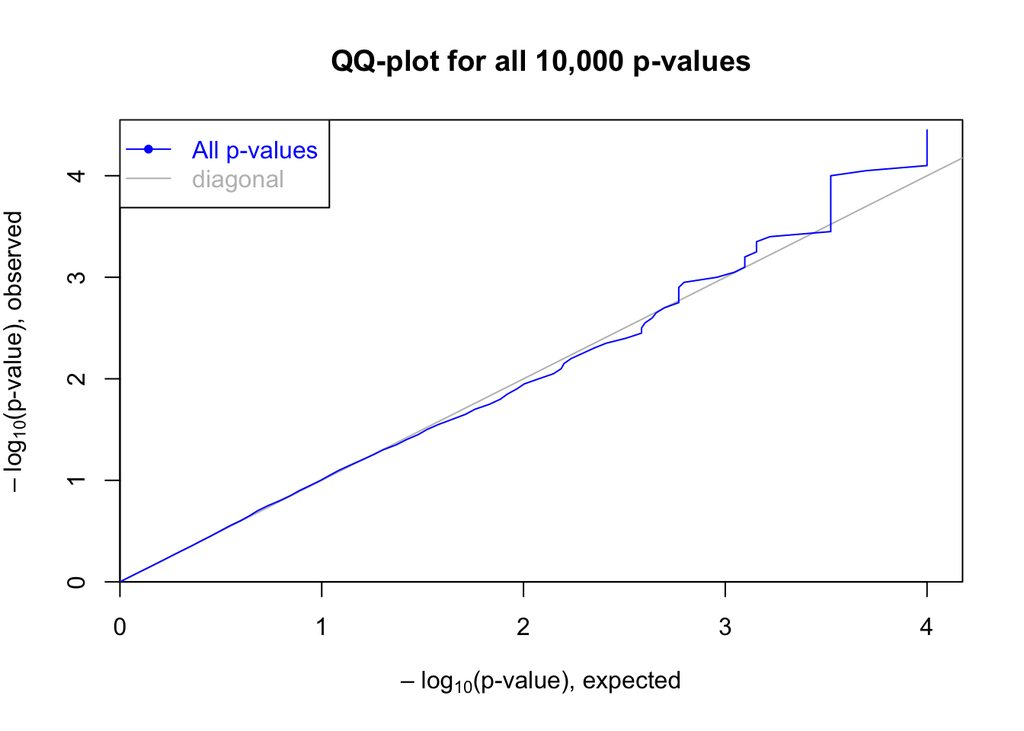

```r
plot(results_mxqtl)
```

```r
head(results_mxqtl$cis$eqtls)
```

```r
nrow(results_mxqtl$cis$eqtls)
```

```r
head(results_mxqtl$cis$ntests)
```

```r
head(results_mxqtl$trans$eqtls)
```

```r
nrow(results_mxqtl$trans$eqtls)
```

```r
head(results_mxqtl$trans$ntests)
```

### Discussion of results

- What is the number of total, cis and trans QTLs?
- What is the qqplot telling us?
- Open the regression results file:
  - What are the lowest raw p-values reported? The highest?
  - What about the beta coefficients?
  - What is the FDR column telling us?
  - Are there any interesting SNP-probe pairs to report?

### Next steps

What could we do next? Annotation, downstream analysis, plots for publication, follow-up of significant results.

### The end

Questions? Corrections? Comments?

## A few references

R Markdown and Notebook:

- [R Markdown](http://rmarkdown.rstudio.com)
- [R Markdown lesson](http://rmarkdown.rstudio.com/lesson-1.html)
- [Overview of R Notebooks at RStudio](http://rmarkdown.rstudio.com/r_notebooks.html#overview)
- [R Markdown Cheat Sheet](https://www.rstudio.com/wp-content/uploads/2016/03/rmarkdown-cheatsheet-2.0.pdf)
- [A tutorial I came across](https://rstudio-pubs-static.s3.amazonaws.com/256225_63ebef4029dd40ef8e3679f6cf200a5a.html#)

Markdown language:

- [The official CommonMark spec](http://spec.commonmark.org/0.28/)
- [Markdown tutorial](http://commonmark.org/help/tutorial/)
- [Quick reference sheet](http://commonmark.org/help/)

QTLs:

- [Quantitative Trait Locus (QTL) Analysis | Learn Science at Scitable](https://www.nature.com/scitable/topicpage/quantitative-trait-locus-qtl-analysis-53904)
- [The role of regulatory variation in complex traits and disease | Nature Reviews Genetics](https://www.nature.com/articles/nrg3891)

Programming with R best practice:

- [Software Carpentry suggestions for best practices with R](http://swcarpentry.github.io/r-novice-inflammation/06-best-practices-R/)

We use Software Carpentry materials for some of the examples and code. Please take a look at their [webpage](https://software-carpentry.org/) and [lessons](https://software-carpentry.org/lessons/) if you are interested.